# Part II - (Presentation on Loan Data from Prosper )

## by (Bright Akachi Daniel)

# **Using Borrower's Feature to Determine Creditworthiness**

## (Visualization 1)

> I will start this presentation my looking at the distribution of some key variables in our dataset starting from LoanStatus and Loan Original Amount.

> For Loan status, it can be seen that the Current loan is the most frequent followed by Completed, Chargedoff, Defaulted Past due(1-15 days), etc. This analysis will focus on the top five most occurring statuses. For Loan Original Amount, the distribution is multimodal, and shows a right skewness. More loans were collected at amounts between $0-11,000.

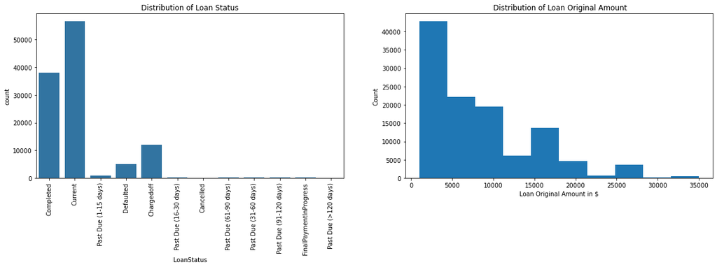

## (Visualization 2)

> Let's see what the distibution of the selected boolean variables of borrowers' features looks like.

> It can be Observed that 50.4% of borrowers are homeowners,11.2% are currently in a group,92.4% are with verifiable income source while 49.6% are not homeowners,88.8% are not currently in a group and 7.6% don't have a verifiable income source.

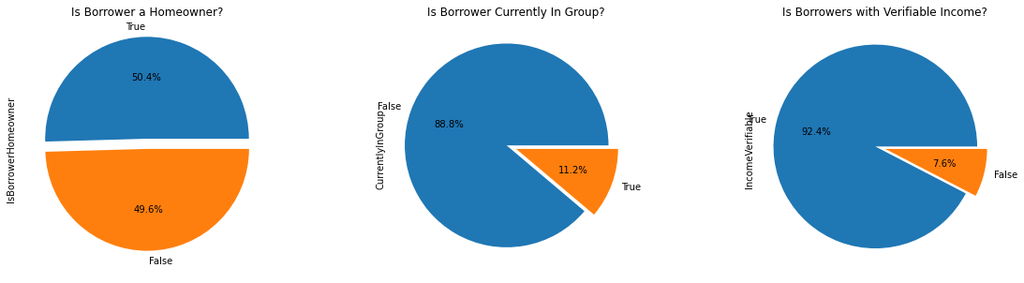

## (Visualization 3)

> Let's see the relationship between Loan Prosper Score and boolean variables below.

> Looking at the mean of Prosper score, it gave the lowest risk score(high prosper score) to borrowers who are homeowners, currently in a group, and with verifiable sources of income as displayed in the bar charts.

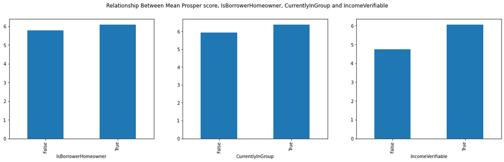

## (Visualization 4)

> Let's see the relationship Between Loan Status,Prosper Score and Loan Original Amount.

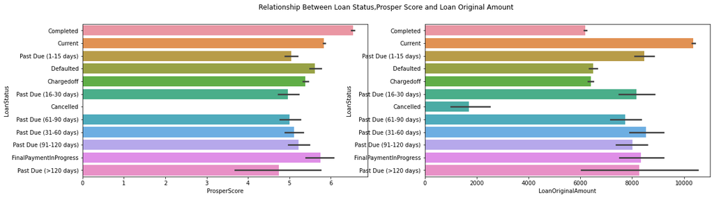

## (Visualization 5)

> Let's visualize the relationship Between Loan Original Amount,IsBorrowerHomeowner,CurrentlyInGroup and IncomeVerifiable.

> Borrowers that are homeowners, with a verifiable sources of income collected higher amounts of the loan compared to their opposites. This can result from the company seeing them as being creditworthy or giving them preference over their opposite pairs. Borrowers who are not in a group collected a higher amount of loans compared to those that are not. This can result from those in a group getting the money needed from the groups they belong to.

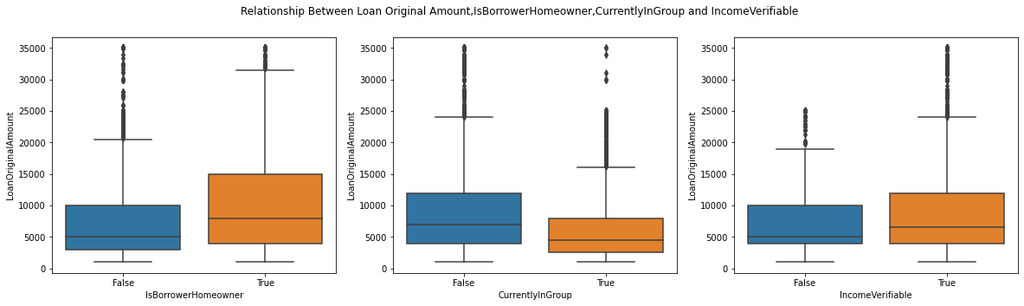

## (Visualization 6)

> Let's visualize the relationship between Loan Original Amount,Loan Status,Occupation and Employment Status.

> Loan Status: Current borrowers have the highest amount of loan while almost the same amount was given to those with completed, charged off, and defaulters.

> Occupation: Executives collected a higher amount of loan than any of the six occupations considered. Computer Programmers, Analysts, and Professionals collected almost the same amount.

> Employment status: As expected, people who are actively employed collected a higher amount than those that are passively and inactively employed.

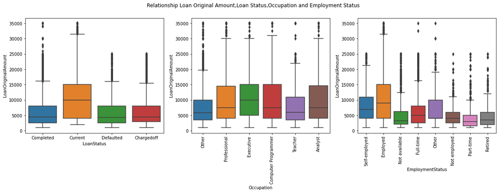

### (Visualization 7)

> Let's continue by visualizing what is the relationship Between Loan Original Amount, Prosper Score,IsBorrowerHomeowner,CurrentlyInGroup and IncomeVerifiable.

> It can be seen that there is a linear relationship between Loan original amount, Prosper score, and the boolean variable being considered, following the same trend as what was observed above.

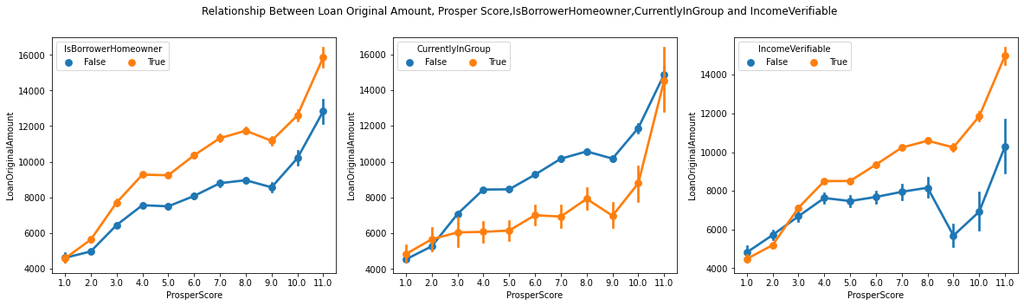

### (Visualization 8)

> Is there any relationship Between Loan Original Amount, Prosper Score, and LoanStatus?

> There exist a linear relationship between the Loan original amount, Prosper score, and the loan statuses been considered, this is more pronounced in the Current status as shown in the regplot below.

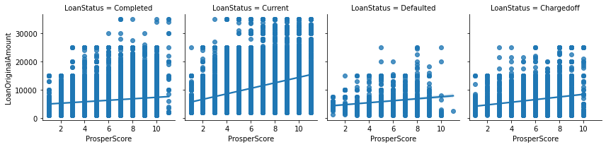

### Visualization 9

> What kind of correlation exist between Loan original amount, Prosper Score and Employment status?

> A linear relationship exists between the Loan original amount, Prosper score, and the employment statuses of Self-employed, employed, other, and not employed. A constant relationship exists between the Loan original amount, Prosper score, and the employment statuses of full-time and retired while there is a negative relationship between the Loan original amount, Prosper score, and part-time employment status. This didn't go as expected, I was expecting a negative correlation to exist between the Loan original amount, Prosper score, and the employment status of Not employed as we have seen in previous trends.

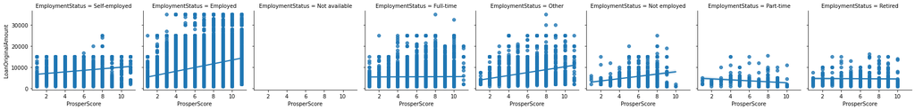

## Conclusion

1. No system is 100% efficient as a saying goes, Prosper score prove to be effective in predicting the risk factor of giving out loans to borrowers based on the features analyzed in this project.
2. There are few deviations due to the distribution of the dataset and this was accounted for at the observations at the end of each variate plot section.
3. The boolean values and the features of the borrower are good to give insight on the credit worthiness of a borrower although some borrowers don't behave in a similar manner.

## Recommendation

I recommend prosper score and the borrowers' futures analyzed in this dataset to be used to determine credit worthiness of a borrower.

People without verifiable source of income,not currently in a group and not employed should be given a small amount of loan so as to reduce defaulting.